# Hướng dẫn phân tích Before-After | Repeated measures

Author

Duc Nguyen

Published

October 30, 2026

[**Tài liệu biên soạn trong chuyên đề R Statistics**](https://www.tuhocr.com/r-statistics)

# 1 Dataset

Dữ liệu được sử dụng theo ví dụ minh họa trang 78 [Verma, J. P. Repeated Measures Design for Empirical Researchers, 2016](https://filedn.com/lesyJpQOCafj7katNqunAxu/THANKS/anova/Verma%20-%20Repeated%20Measures%20Design%20for%20Empirical%20Researchers.pdf). [[`data_oneway_anova_repeated.xlsx`]](https://filedn.com/lesyJpQOCafj7katNqunAxu/TUHOCR/STAT/202610_grow_K1/dataset/data_oneway_anova_repeated.xlsx)

Bố trí thí nghiệm theo dõi tác động của việc “ngồi thiền/meditation” qua 6 tuần (biến yếu tố thời gian) đến “khả năng suy luận/reasoning ability” (biến outcome) của 10 người tham gia (biến ngẫu nhiên).

Dữ liệu có:

10 đối tượng: S1–S10

4 lần đo: week_0, week_2, week_4, week_6

Cùng một đối tượng được đo lặp lại ở cả 4 thời điểm.

```r
library(readxl)
df <- read_excel("data_oneway_anova_repeated.xlsx")

df <- as.data.frame(df)

df
```

```
   subject week_0 week_2 week_4 week_6
1       S1     31     36     35     37
2       S2     31     34     34     35
3       S3     32     31     37     35
4       S4     30     32     36     35
5       S5     34     33     37     37
6       S6     35     34     36     38
7       S7     36     31     31     38
8       S8     36     35     30     40
9       S9     32     31     35     36
10     S10     33     32     34     36
```

**Lấy factor cột `subject`**

```r
df$subject <- factor(df$subject,
                     levels = c("S1", "S2", "S3", "S4", "S5",
                                "S6", "S7", "S8", "S9", "S10"))
```

**Chuyển về dạng long**

```r
library(dplyr)
library(tidyr)

df %>% tidyr:::pivot_longer(

  cols = 2:5,
  names_to = "week",
  values_to = "score"

) -> df_long

df_long <- as.data.frame(df_long)

df_long |> dplyr:::arrange(subject, week) -> df_long

df_long
```

```
   subject   week score
1       S1 week_0    31
2       S1 week_2    36
3       S1 week_4    35
4       S1 week_6    37
5       S2 week_0    31
6       S2 week_2    34
7       S2 week_4    34
8       S2 week_6    35
9       S3 week_0    32
10      S3 week_2    31
11      S3 week_4    37
12      S3 week_6    35
13      S4 week_0    30
14      S4 week_2    32
```

[output cut: 26 more lines]

# 2 Mô tả dữ liệu

```r
df_long |> dplyr:::group_by(week) |>
  dplyr:::summarise(mean_score = mean(score),
                    sd_score = sd(score),
                    count = n()) |> as.data.frame() -> df_sum

df_sum$se_score <- df_sum$sd_score / sqrt(df_sum$count)

df_sum$note <- "subject_mean"

df_sum
```

```
    week mean_score sd_score count  se_score         note
1 week_0       33.0 2.160247    10 0.6831301 subject_mean
2 week_2       32.9 1.791957    10 0.5666667 subject_mean
3 week_4       34.5 2.368778    10 0.7490735 subject_mean
4 week_6       36.7 1.636392    10 0.5174725 subject_mean
```

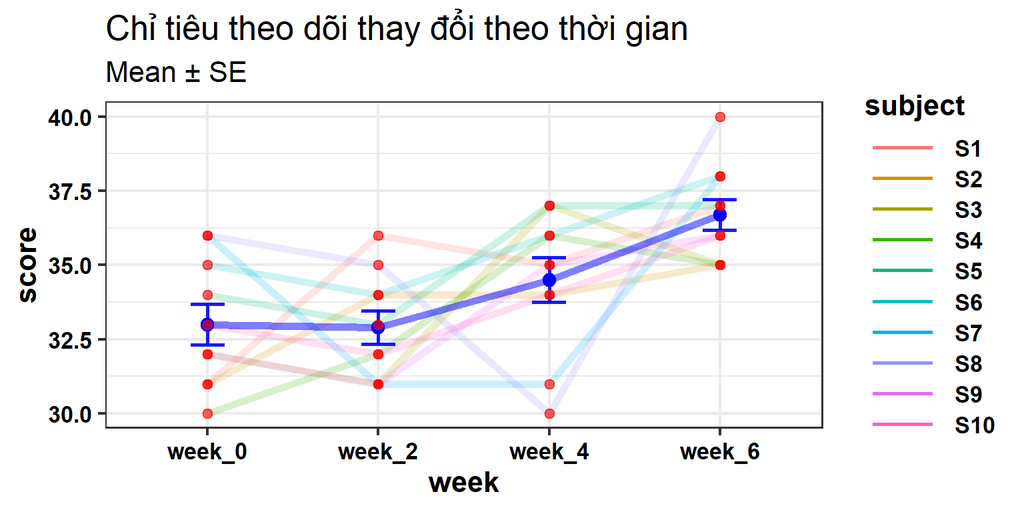

```r
library(ggplot2)

ggplot() +

  geom_line(data = df_long,
       mapping = aes(x = week,
                     y = score,
                     group = subject,
                     color = subject),
       alpha = 0.2,
       lwd = 2) +



  geom_point(data = df_sum,
            mapping = aes(x = week,
                          y = mean_score),
            size = 3,
            color = "blue") +

  geom_line(data = df_sum,
            mapping = aes(x = week,
                          y = mean_score,
                          group = note),
            color = "blue",
            alpha = 0.5,
            lwd = 2) +

  geom_errorbar(data = df_sum,
            mapping = aes(x = week,
                          ymin = mean_score - se_score,
                          ymax = mean_score + se_score,
                          group = note),
            color = "blue",
            alpha = 0.9,
            lwd = 1,
            width = 0.2) +

  guides(color = guide_legend(override.aes = list(alpha = 1,
                                                  lwd = 1))) +

  theme_bw(base_size = 16) +

  theme(axis.text = element_text(face = "bold", color = "black"),
        axis.title = element_text(face = "bold", color = "black"),

        legend.text = element_text(face = "bold", color = "black"),
        legend.title = element_text(face = "bold", color = "black")) +

  theme(legend.key.width = unit(1.5, "cm")) +

  labs(title = "Chỉ tiêu theo dõi thay đổi theo thời gian",
       subtitle = "Mean ± SE") +

   geom_point(data = df_long,
       mapping = aes(x = week,
                     y = score,
                     group = subject),
       position = position_jitter(height = 0,
                                  width = 0),
       color = "red",
       alpha = 0.6)
```

# 3 Mở đầu

ANOVA thông thường (one-way ANOVA) là dạng thiết kế nghiên cứu để so sánh giữa các nhóm đối tượng với nhau, mỗi đối tượng chỉ đo một lần, không lặp lại (between-subjects design).

Repeated measures one-way ANOVA là dạng thiết kế nghiên cứu theo dõi cùng 1 đối tượng ở các thời điểm khác nhau (repeated measures), có đặc điểm là mỗi đối tượng tự làm nhóm đối chứng cho chính mình, loại bỏ được phần biến thiên giữa các cá nhân và chỉ kiểm định đúng sự thay đổi trong nội bộ từng người (within-subjects design).

Khi xét ở 2 thời điểm, repeated measures ANOVA và paired t-test cho kết quả giống hệt nhau, vì bản chất repeated measures ANOVA là paired t-test cho trường hợp so sánh từ 2 thời điểm trở lên.

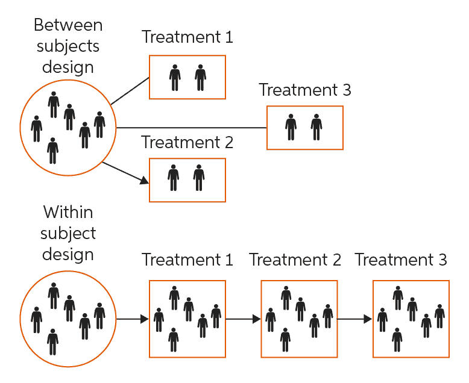

Ưu và nhược của thiết kế này [link](https://filedn.com/lesyJpQOCafj7katNqunAxu/THANKS/anova/Verma%20-%20Repeated%20Measures%20Design%20for%20Empirical%20Researchers.pdf#page=98).

# 4 Phân tích paired t-test | `week_0` và `week_6`

```r
df_paired <- df[ , c(1, 2, 5)]

df_paired
```

```
   subject week_0 week_6
1       S1     31     37
2       S2     31     35
3       S3     32     35
4       S4     30     35
5       S5     34     37
6       S6     35     38
7       S7     36     38
8       S8     36     40
9       S9     32     36
10     S10     33     36
```

```r
t.test(df$week_0,
       df$week_6,
       var.equal = T,
       paired = T)
```

```
    Paired t-test

data:  df$week_0 and df$week_6
t = -10.091, df = 9, p-value = 3.318e-06
alternative hypothesis: true mean difference is not equal to 0
95 percent confidence interval:
 -4.529458 -2.870542
sample estimates:
mean difference
           -3.7
```

```r
t.test(df$week_0,
       df$week_6,
       var.equal = F,
       paired = T)
```

```
    Paired t-test

data:  df$week_0 and df$week_6
t = -10.091, df = 9, p-value = 3.318e-06
alternative hypothesis: true mean difference is not equal to 0
95 percent confidence interval:
 -4.529458 -2.870542
sample estimates:
mean difference
           -3.7
```

```r
wilcox.test(df$week_0,
            df$week_6,
       var.equal = T,
       paired = T,
       exact = F)
```

```
    Wilcoxon signed rank test with continuity correction

data:  df$week_0 and df$week_6
V = 0, p-value = 0.005479
alternative hypothesis: true location shift is not equal to 0
```

```r
library(tidyr)
library(dplyr)

df_paired %>% tidyr:::pivot_longer(

  cols = 2:3,
  names_to = "week",
  values_to = "score"

) -> df_paired_long

df_paired_long |> dplyr:::arrange(week, subject) -> df_paired_long

df_paired_long
```

```
# A tibble: 20 × 3
   subject week   score
   <fct>   <chr>  <dbl>
 1 S1      week_0    31
 2 S2      week_0    31
 3 S3      week_0    32
 4 S4      week_0    30
 5 S5      week_0    34
 6 S6      week_0    35
 7 S7      week_0    36
 8 S8      week_0    36
 9 S9      week_0    32
10 S10     week_0    33
11 S1      week_6    37
12 S2      week_6    35
13 S3      week_6    35
14 S4      week_6    35
15 S5      week_6    37
16 S6      week_6    38
17 S7      week_6    38
18 S8      week_6    40
19 S9      week_6    36
20 S10     week_6    36
```

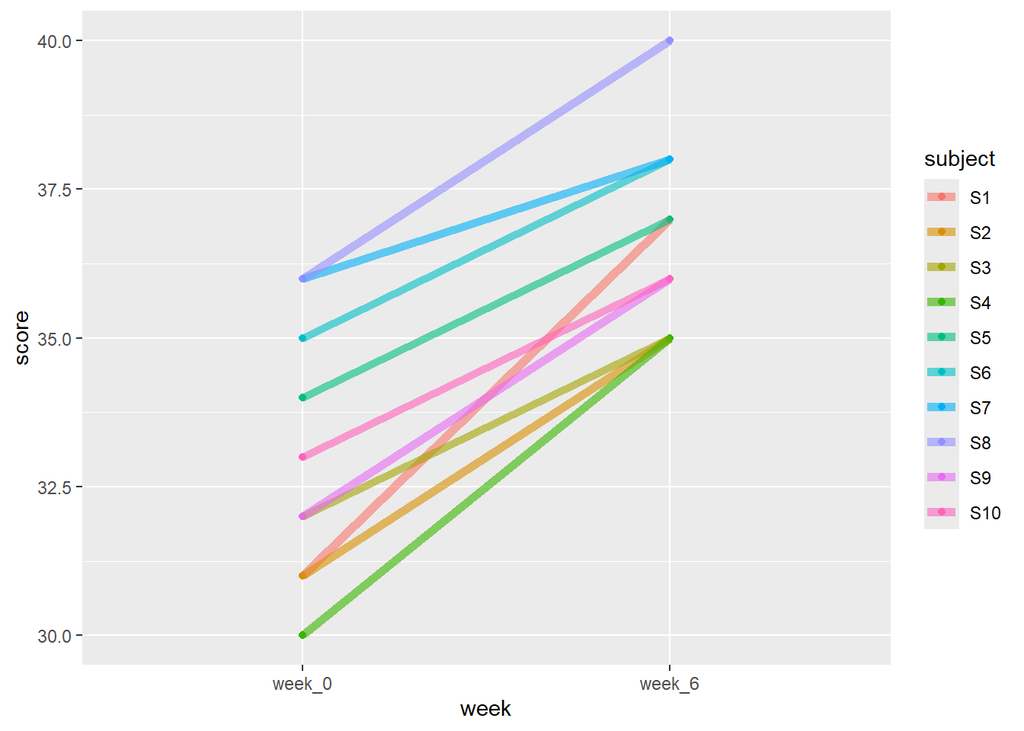

```r
library(ggplot2)

ggplot(data = df_paired_long,
       mapping = aes(x = week,
                     y = score,
                     group = subject,
                     color = subject)) +

  geom_point() +

  geom_line(lwd = 2,
            alpha = 0.6)
```

```r
library(ggstatsplot
        )
p1 <- ggstatsplot:::ggwithinstats(data = df_paired_long,
                     x = week,
                     y = score,
                     type = "parametric",
                     var.equal = TRUE,
                     plot.type = "box",
                     pairwise.comparisons = T,
                     pairwise.display = "all",
                     p.adjust.method = "none",
                     centrality.plotting = T,
                     centrality.path = T,
                     digits = 4L,
                     ggtheme = theme_classic(base_size = 12),
                     bf.message = T,
                     results.subtitle = T,
                     caption = "",
                     centrality.point.args = list(size = 4, color = "darkred"),
                     centrality.label.args = list(size = 4,
                                                  nudge_x = 0.4,
                                                  segment.linetype = 4),
                     ggsignif.args = list(size = 0.5,
                                          vjust = 0,
                                          step_increase = 0.1,
                                          textsize = 5),
                     point.path.args = list(alpha = 0.5,
                                            lwd = 0.8,
                                            linetype = "solid",
                                            color = "blue"),
                     point.args = list(position = ggplot2::position_jitterdodge(dodge.width = 0,                                                                 jitter.width = 0,                                                                jitter.height = 0),
                                       alpha = 0.5,
                                       size = 6,
                                       stroke = 0,
                                       na.rm = TRUE)
                     )

ggsave(filename = "p1_paired_ok.png",
       width = 8,
       height = 6,
       plot = p1,
       dpi = 300,
       units = "in")
```

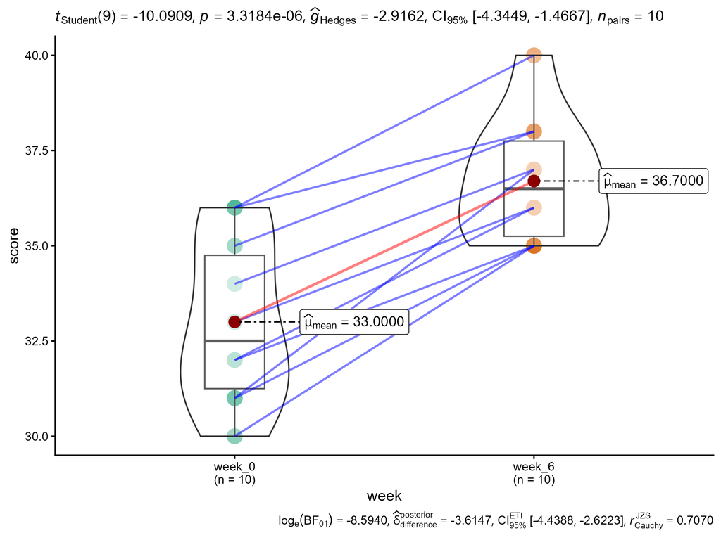

# 5 Phân tích repeated measures ANOVA | parametric

Tham khảo [#1](https://numiqo.com/tutorial/anova-with-repeated-measures)

## 5.1 Giả định về phân bố chuẩn

Mỗi tuần ta đều khảo sát trên 10 người, ta muốn đánh giá xem trung bình chỉ số “suy luận” có thay đổi theo từng tuần này không. Như vậy “week” là biến yếu tố. Ta xem xét dữ liệu ở từng tuần có tuân theo phân bố chuẩn hay không.

**Dùng kiểm định Shapiro-Wilk Normality Test**

```r
library(rstatix)

df_long %>% dplyr:::group_by(week) %>% rstatix:::shapiro_test(score) |> as.data.frame()
```

```
    week variable statistic         p
1 week_0    score 0.9241773 0.3931157
2 week_2    score 0.9046545 0.2462523
3 week_4    score 0.8794111 0.1284765
4 week_6    score 0.9016076 0.2281626
```

```r
library(MVN)

MVN:::mvn(df[, -1])
```

```
$multivariate_normality
           Test Statistic p.value     Method      MVN
1 Henze-Zirkler     0.736   0.148 asymptotic ✓ Normal

$univariate_normality
              Test Variable Statistic p.value Normality
1 Anderson-Darling   week_0     0.318   0.475  ✓ Normal
2 Anderson-Darling   week_2     0.389   0.313  ✓ Normal
3 Anderson-Darling   week_4     0.515   0.144  ✓ Normal
4 Anderson-Darling   week_6     0.392   0.307  ✓ Normal

$descriptives
  Variable  n Mean Std.Dev Median Min Max  25th  75th   Skew Kurtosis
1   week_0 10 33.0   2.160   32.5  30  36 31.25 34.75  0.209    1.667
2   week_2 10 32.9   1.792   32.5  31  36 31.25 34.00  0.401    1.857
3   week_4 10 34.5   2.369   35.0  30  37 34.00 36.00 -0.846    2.543
4   week_6 10 36.7   1.636   36.5  35  40 35.25 37.75  0.667    2.580

$data
   week_0 week_2 week_4 week_6
1      31     36     35     37
2      31     34     34     35
3      32     31     37     35
4      30     32     36     35
5      34     33     37     37
6      35     34     36     38
7      36     31     31     38
8      36     35     30     40
9      32     31     35     36
10     33     32     34     36

$subset
NULL

$outlierMethod
[1] "none"

attr(,"class")
[1] "mvn"
```

p-value > 0.05 là dữ liệu có phân bố chuẩn.

**Dùng đồ thị QQ plot**

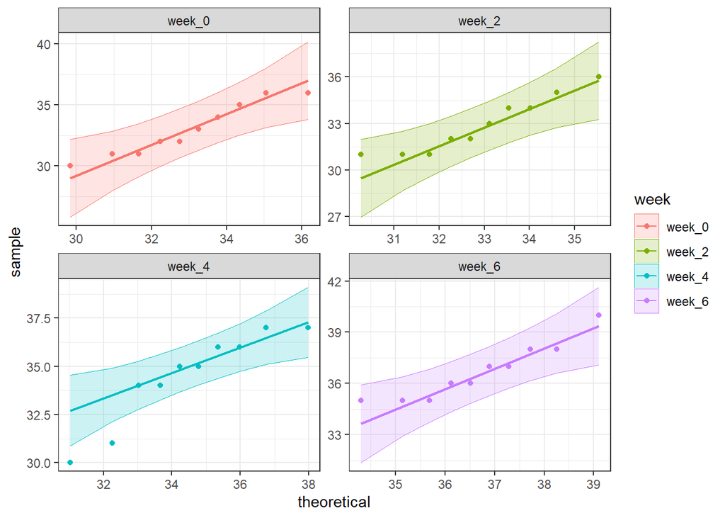

```r
library(ggplot2)
library(qqplotr)
ggplot(data = df_long,
       mapping = aes(sample = score,
                     color = week,
                     fill = week)) +

    qqplotr:::stat_qq_band(alpha = 0.2) +

    qqplotr:::stat_qq_line() +

    qqplotr:::stat_qq_point() +

    facet_wrap(~ week,
               scale = "free",
               nrow = 2,
               ncol = 2) +

  theme_bw()
```

Hầu như các điểm dữ liệu đều nằm trong vùng 95% CI của đường reference line nên dữ liệu phân bố chuẩn.

**Kiểm tra outlier**

```r
library(rstatix)

df_long %>% dplyr:::group_by(week) %>% rstatix:::identify_outliers(score) |> as.data.frame()
```

```
    week subject score is.outlier is.extreme
1 week_4      S8    30       TRUE      FALSE
```

Có 1 giá trị được xem như outlier. Ta có thể giữ lại giá trị này hoặc loại bỏ, tùy vào quyết định chuyên môn. Ở đây ta vẫn giữ lại giá trị này.

## 5.2 Giả định về sphericity

Sphericity is an important assumption of a repeated-measures ANOVA. It is the condition of equal variances among the differences between all possible pairs of within-subject conditions (i.e., levels of the independent variable).

If sphericity is violated (i.e., if the variances of the differences between all combinations of the conditions are not equal), then the variance calculations may be distorted, which would result in an inflated F-ratio.

Phương sai của hiệu số giữa mọi cặp điều kiện phải bằng nhau. Nếu vi phạm, phải hiệu chỉnh bậc tự do bằng Greenhouse-Geisser (GG) hoặc Huynh-Feldt (HF).

H0: Phương sai giữa các thời điểm đo bằng nhau.

H1: Phương sai giữa các thời điểm đo KHÔNG bằng nhau.

Kết quả này cũng được *tính toán chung* với lệnh `rstatix:::anova_test()` khi thực hiện kiểm định one-way repeated measures ANOVA ở bước tiếp theo.

```r
df_m <- as.matrix(df[, -1])

# names(dimnames(df_m)) <- c("subject", "week")
# row.names(df_m) <- df$subject

fit <- lm(df_m ~ 1)

stats::mauchly.test(
  fit,
  X = ~1)
```

```
    Mauchly's test of sphericity
    Contrasts orthogonal to
    ~1


data:  SSD matrix from lm(formula = df_m ~ 1)
W = 0.062256, p-value = 0.0007488
```

## 5.3 One-way repeated measures ANOVA

H0: Trung bình số điểm ở các tuần không thay đổi (thời gian không phải là yếu tố tác động đến số điểm). Hay là: không có sự khác biệt về số điểm trung bình của bệnh nhân ở 4 thời điểm theo dõi $\mu_0 = \mu_2 = \mu_4 = \mu_6$

H1: Có ít nhất một thời điểm có số điểm trung bình khác biệt so với các thời điểm còn lại

### 5.3.1 Cách 1: Dùng package `rstatix`

```r
# để xuất ra nhiều số thập phân hơn, bạn thay đổi giá trị của hàm anova_summary()

# results <- results %>% map(~dplyr::mutate_if(., is.numeric,
#     round_value, 3)) # thay số 3 thành số 8

# bằng lệnh này
# trace("anova_summary", edit = T)
```

```r
res.aov <- rstatix:::anova_test(data = df_long,
                                dv = score,
                                wid = subject,
                                within = week)
res.aov
```

```
ANOVA Table (type III tests)

$ANOVA
  Effect DFn DFd     F        p p<.05   ges
1   week   3  27 7.281 0.000992     * 0.394

$`Mauchly's Test for Sphericity`
  Effect     W        p p<.05
1   week 0.062 0.000749     *

$`Sphericity Corrections`
  Effect   GGe      DF[GG] p[GG] p[GG]<.05  HFe      DF[HF] p[HF] p[HF]<.05
1   week 0.546 1.64, 14.73 0.009         * 0.65 1.95, 17.56 0.005         *
```

Lưu ý là kết quả là p-value của ANOVA chưa hiệu chỉnh với sphericity. Vì giả định sphericity bị vi phạm, nên ta sẽ dùng p-value của dòng `Sphericity Corrections`

```r
res.aov$ANOVA
```

```
  Effect DFn DFd     F        p p<.05   ges
1   week   3  27 7.281 0.000992     * 0.394
```

**Dùng kết quả này để báo cáo p-value cho one-way repeated measures ANOVA**

[GG] là viết tắt của việc hiệu chỉnh p-value theo Greenhouse-Geisser

```r
res.aov$`Sphericity Corrections`
```

```
  Effect   GGe      DF[GG] p[GG] p[GG]<.05  HFe      DF[HF] p[HF] p[HF]<.05
1   week 0.546 1.64, 14.73 0.009         * 0.65 1.95, 17.56 0.005         *
```

Cột `ges` (generalized eta-squared $\eta^2$) trong bảng ANOVA chính là effect size là 0.394, cho thấy hiệu ứng khá lớn, kết quả này thuyết phục.

Effect size của (partial) eta squared: < 0.01 là small, < 0.06 là medium, < 0.14 là large.

Điều này có nghĩa là 39.4% phương sai của điểm số được giải thích bởi yếu tố thời gian.

p[GG] = 0.009 < 0.05 vẫn có sự khác biệt có ý nghĩa thống kê giữa các thời điểm. Thời điểm có ảnh hưởng có ý nghĩa thống kê đến outcome.

```r
get_anova_table(res.aov,
                correction = "none")
```

```
ANOVA Table (type III tests)

  Effect DFn DFd     F        p p<.05   ges
1   week   3  27 7.281 0.000992     * 0.394
```

```r
# when sphericity is violated, get_anova_table() applies the Greenhouse-Geisser correction automatically

get_anova_table(res.aov,
                correction = "GG")
```

```
ANOVA Table (type III tests)

  Effect  DFn   DFd     F     p p<.05   ges
1   week 1.64 14.73 7.281 0.009     * 0.394
```

```r
get_anova_table(res.aov,
                correction = "HF")
```

```
ANOVA Table (type III tests)

  Effect  DFn   DFd     F     p p<.05   ges
1   week 1.95 17.56 7.281 0.005     * 0.394
```

### 5.3.2 Cách 2: Dùng package `car`

```r
library(car)
Y <- cbind(
  week_0 = df$week_0,
  week_2 = df$week_2,
  week_4 = df$week_4,
  week_6 = df$week_6
)

fit <- lm(Y ~ 1)

idata <- data.frame(
  week = factor(
    c("week_0", "week_2", "week_4", "week_6")
  )
)

fit_rm <- car:::Anova(
  fit,
  idata = idata,
  idesign = ~ week
)

summary(fit_rm,
        multivariate = F,
        univariate = T)
```

```
Univariate Type III Repeated-Measures ANOVA Assuming Sphericity

            Sum Sq num Df Error SS den Df    F value    Pr(>F)
(Intercept)  46991      1   28.725      9 14723.0366 8.908e-16 ***
week            94      3  116.775     27     7.2813 0.0009922 ***
---
Signif. codes:  0 '***' 0.001 '**' 0.01 '*' 0.05 '.' 0.1 ' ' 1


Mauchly Tests for Sphericity

     Test statistic    p-value
week       0.062256 0.00074876


Greenhouse-Geisser and Huynh-Feldt Corrections
 for Departure from Sphericity

      GG eps Pr(>F[GG])
week 0.54554   0.008644 **
---
Signif. codes:  0 '***' 0.001 '**' 0.01 '*' 0.05 '.' 0.1 ' ' 1

        HF eps  Pr(>F[HF])
week 0.6503498 0.005212001
```

```r
summary(fit_rm,
        multivariate = T,
        univariate = T)
```

```
Type III Repeated Measures MANOVA Tests:

------------------------------------------

Term: (Intercept)

 Response transformation matrix:
       (Intercept)
week_0           1
week_2           1
week_4           1
week_6           1

Sum of squares and products for the hypothesis:
            (Intercept)
(Intercept)    187964.1

Multivariate Tests: (Intercept)
                 Df test stat approx F num Df den Df     Pr(>F)
Pillai            1    0.9994 14723.04      1      9 8.9083e-16 ***
Wilks             1    0.0006 14723.04      1      9 8.9083e-16 ***
Hotelling-Lawley  1 1635.8930 14723.04      1      9 8.9083e-16 ***
Roy               1 1635.8930 14723.04      1      9 8.9083e-16 ***
---
Signif. codes:  0 '***' 0.001 '**' 0.01 '*' 0.05 '.' 0.1 ' ' 1

------------------------------------------

Term: week

 Response transformation matrix:
       week1 week2 week3
week_0     1     0     0
week_2     0     1     0
week_4     0     0     1
week_6    -1    -1    -1

Sum of squares and products for the hypothesis:
      week1 week2 week3
week1 136.9 140.6  81.4
```

[output cut: 22 more lines]

```

     Test statistic    p-value
week       0.062256 0.00074876


Greenhouse-Geisser and Huynh-Feldt Corrections
 for Departure from Sphericity

      GG eps Pr(>F[GG])
week 0.54554   0.008644 **
---
Signif. codes:  0 '***' 0.001 '**' 0.01 '*' 0.05 '.' 0.1 ' ' 1

        HF eps  Pr(>F[HF])
week 0.6503498 0.005212001
```

### 5.3.3 Cách 3: Dùng package `afex`

```r
library(afex)
fit <- afex:::aov_ez(
  id = "subject",
  dv = "score",
  within = "week",
  data = df_long
)

fit
```

```
Anova Table (Type 3 tests)

Response: score
  Effect          df  MSE       F  ges p.value
1   week 1.64, 14.73 7.93 7.28 ** .394    .009
---
Signif. codes:  0 '***' 0.001 '**' 0.01 '*' 0.05 '+' 0.1 ' ' 1

Sphericity correction method: GG
```

```r
# yêu cầu báo cáo partial eta squared.
afex:::nice(
  fit,
  correction = "none",
  es = "pes"
)
```

```
Anova Table (Type 3 tests)

Response: score
  Effect    df  MSE        F  pes p.value
1   week 3, 27 4.32 7.28 *** .447   <.001
---
Signif. codes:  0 '***' 0.001 '**' 0.01 '*' 0.05 '+' 0.1 ' ' 1
```

```r
afex:::nice(
  fit,
  correction = "GG",
  es = "pes"
)
```

```
Anova Table (Type 3 tests)

Response: score
  Effect          df  MSE       F  pes p.value
1   week 1.64, 14.73 7.93 7.28 ** .447    .009
---
Signif. codes:  0 '***' 0.001 '**' 0.01 '*' 0.05 '+' 0.1 ' ' 1

Sphericity correction method: GG
```

```r
afex:::nice(
  fit,
  correction = "HF",
  es = "pes"
)
```

```
Anova Table (Type 3 tests)

Response: score
  Effect          df  MSE       F  pes p.value
1   week 1.95, 17.56 6.65 7.28 ** .447    .005
---
Signif. codes:  0 '***' 0.001 '**' 0.01 '*' 0.05 '+' 0.1 ' ' 1

Sphericity correction method: HF
```

### 5.3.4 Cách 4: dùng package `ez`

`https://rpubs.com/mwymelody830/RM-ANOVA`

```r
library(ez)
df_long$week <- factor(df_long$week)
output <- ez:::ezANOVA(df_long,
                       dv = .(score),
                       wid = .(subject),
                       within = .(week),
                       type = 2)

output
```

```
$ANOVA
  Effect DFn DFd       F            p p<.05       ges
2   week   3  27 7.28131 0.0009922252     * 0.3936868

$`Mauchly's Test for Sphericity`
  Effect          W            p p<.05
2   week 0.06225602 0.0007487556     *

$`Sphericity Corrections`
  Effect       GGe       p[GG] p[GG]<.05       HFe       p[HF] p[HF]<.05
2   week 0.5455433 0.008644213         * 0.6503498 0.005212001         *
```

### 5.3.5 Cách 5: Dùng base R

```r
output <- aov(score ~ week + Error(factor(subject)/week),
             data = df_long)
summary(output)
```

```
Error: factor(subject)
          Df Sum Sq Mean Sq F value Pr(>F)
Residuals  9  28.73   3.192

Error: factor(subject):week
          Df Sum Sq Mean Sq F value   Pr(>F)
week       3  94.48  31.492   7.281 0.000992 ***
Residuals 27 116.77   4.325
---
Signif. codes:  0 '***' 0.001 '**' 0.01 '*' 0.05 '.' 0.1 ' ' 1
```

## 5.4 Post-hoc multiple comparison

Sau khi Repeated Measures ANOVA cho kết quả có ý nghĩa thống kê, cần thực hiện multiple comparisons để xác định cụ thể thời điểm nào có sự khác biệt.

Vì các phép đo được thực hiện trên cùng một bệnh nhân, sử dụng paired t-test cho từng cặp thời điểm và điều chỉnh p-value bằng Bonferroni.

### 5.4.1 Cách 1

```r
pairwise_result <- df_long %>%
  pairwise_t_test(
    score ~ week,
    paired = TRUE, # LƯU Ý LÀ PAIRED = TRUE VÌ GHÉP CẶP
    p.adjust.method = "bonferroni"
  )

pairwise_result |> as.data.frame() -> kq

kq
```

```
    .y. group1 group2 n1 n2   statistic df        p    p.adj p.adj.signif
1 score week_0 week_2 10 10   0.1142909  9 9.12e-01 1.00e+00           ns
2 score week_0 week_4 10 10  -1.1838007  9 2.67e-01 1.00e+00           ns
3 score week_0 week_6 10 10 -10.0909091  9 3.32e-06 1.99e-05         ****
4 score week_2 week_4 10 10  -1.5790841  9 1.49e-01 8.94e-01           ns
5 score week_2 week_6 10 10  -6.6261154  9 9.63e-05 5.78e-04          ***
6 score week_4 week_6 10 10  -1.9084393  9 8.90e-02 5.32e-01           ns
```

Diễn giải kết quả:

### 5.4.2 Cách 2

```r
library(ggpubr)

pwc <- df_long %>%
  pairwise_t_test(score ~ week,
                  paired = TRUE,
                  p.adjust.method = "bonferroni")

pwc <- pwc %>% add_xy_position(x = "week")

pwc -> pwc_ori

pwc_ori <- as.data.frame(pwc_ori)

pwc_ori
```

```
    .y. group1 group2 n1 n2   statistic df        p    p.adj p.adj.signif y.position         groups xmin xmax
1 score week_0 week_2 10 10   0.1142909  9 9.12e-01 1.00e+00           ns     40.480 week_0, week_2    1    2
2 score week_0 week_4 10 10  -1.1838007  9 2.67e-01 1.00e+00           ns     41.056 week_0, week_4    1    3
3 score week_0 week_6 10 10 -10.0909091  9 3.32e-06 1.99e-05         ****     41.632 week_0, week_6    1    4
4 score week_2 week_4 10 10  -1.5790841  9 1.49e-01 8.94e-01           ns     42.208 week_2, week_4    2    3
5 score week_2 week_6 10 10  -6.6261154  9 9.63e-05 5.78e-04          ***     42.784 week_2, week_6    2    4
6 score week_4 week_6 10 10  -1.9084393  9 8.90e-02 5.32e-01           ns     43.360 week_4, week_6    3    4
```

### 5.4.3 Cách 3

#### 5.4.3.1 Hiệu chỉnh theo random effect của `subject`

```r
library(emmeans)

fit <- afex::aov_ez(
  id = "subject",
  dv = "score",
  within = "week",
  data = df_long
)

summary(fit)
```

```
Univariate Type III Repeated-Measures ANOVA Assuming Sphericity

            Sum Sq num Df Error SS den Df    F value    Pr(>F)
(Intercept)  46991      1   28.725      9 14723.0366 8.908e-16 ***
week            94      3  116.775     27     7.2813 0.0009922 ***
---
Signif. codes:  0 '***' 0.001 '**' 0.01 '*' 0.05 '.' 0.1 ' ' 1


Mauchly Tests for Sphericity

     Test statistic    p-value
week       0.062256 0.00074876


Greenhouse-Geisser and Huynh-Feldt Corrections
 for Departure from Sphericity

      GG eps Pr(>F[GG])
week 0.54554   0.008644 **
---
Signif. codes:  0 '***' 0.001 '**' 0.01 '*' 0.05 '.' 0.1 ' ' 1

        HF eps  Pr(>F[HF])
week 0.6503498 0.005212001
```

```r
emmeans(
  fit,
  pairwise ~ week,
  adjust = "holm"
)
```

```
$emmeans
 week   emmean    SE df lower.CL upper.CL
 week_0   33.0 0.683  9     31.5     34.5
 week_2   32.9 0.567  9     31.6     34.2
 week_4   34.5 0.749  9     32.8     36.2
 week_6   36.7 0.517  9     35.5     37.9

Confidence level used: 0.95

$contrasts
 contrast        estimate    SE df t.ratio p.value
 week_0 - week_2      0.1 0.875  9   0.114  0.9115
 week_0 - week_4     -1.5 1.270  9  -1.184  0.5336
 week_0 - week_6     -3.7 0.367  9 -10.091 <0.0001
 week_2 - week_4     -1.6 1.010  9  -1.579  0.4463
 week_2 - week_6     -3.8 0.573  9  -6.626  0.0005
 week_4 - week_6     -2.2 1.150  9  -1.908  0.3547

P value adjustment: holm method for 6 tests
```

```r
emm <- emmeans(fit, ~ week)

pairs(
  emm,
  adjust = "holm"
)
```

```
 contrast        estimate    SE df t.ratio p.value
 week_0 - week_2      0.1 0.875  9   0.114  0.9115
 week_0 - week_4     -1.5 1.270  9  -1.184  0.5336
 week_0 - week_6     -3.7 0.367  9 -10.091 <0.0001
 week_2 - week_4     -1.6 1.010  9  -1.579  0.4463
 week_2 - week_6     -3.8 0.573  9  -6.626  0.0005
 week_4 - week_6     -2.2 1.150  9  -1.908  0.3547

P value adjustment: holm method for 6 tests
```

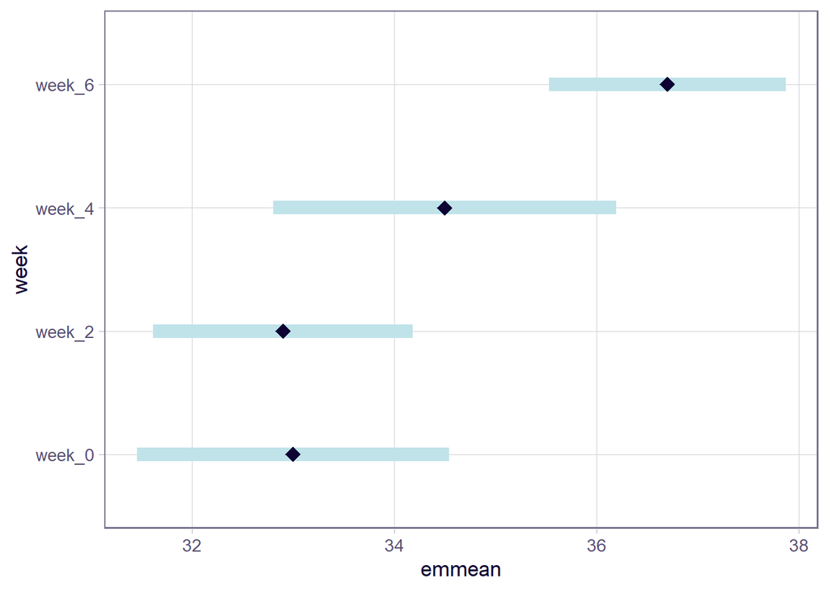

```r
# plot(emm)

emmeans:::plot.emmGrid(emm)
```

#### 5.4.3.2 Tính theo kiểu ANOVA thông thường

Ta thấy kết quả có hiệu chỉnh lại đôi chút.

```r
fit <- aov(score ~ week, data= df_long)

emmeans(
  fit,
  pairwise ~ week,
  adjust = "holm"
)
```

```
$emmeans
 week   emmean    SE df lower.CL upper.CL
 week_0   33.0 0.636 36     31.7     34.3
 week_2   32.9 0.636 36     31.6     34.2
 week_4   34.5 0.636 36     33.2     35.8
 week_6   36.7 0.636 36     35.4     38.0

Confidence level used: 0.95

$contrasts
 contrast        estimate    SE df t.ratio p.value
 week_0 - week_2      0.1 0.899 36   0.111  0.9121
 week_0 - week_4     -1.5 0.899 36  -1.668  0.2508
 week_0 - week_6     -3.7 0.899 36  -4.115  0.0011
 week_2 - week_4     -1.6 0.899 36  -1.780  0.2508
 week_2 - week_6     -3.8 0.899 36  -4.227  0.0009
 week_4 - week_6     -2.2 0.899 36  -2.447  0.0777

P value adjustment: holm method for 6 tests
```

```r
emm <- emmeans(fit, ~ week)

pairs(
  emm,
  adjust = "holm"
)
```

```
 contrast        estimate    SE df t.ratio p.value
 week_0 - week_2      0.1 0.899 36   0.111  0.9121
 week_0 - week_4     -1.5 0.899 36  -1.668  0.2508
 week_0 - week_6     -3.7 0.899 36  -4.115  0.0011
 week_2 - week_4     -1.6 0.899 36  -1.780  0.2508
 week_2 - week_6     -3.8 0.899 36  -4.227  0.0009
 week_4 - week_6     -2.2 0.899 36  -2.447  0.0777

P value adjustment: holm method for 6 tests
```

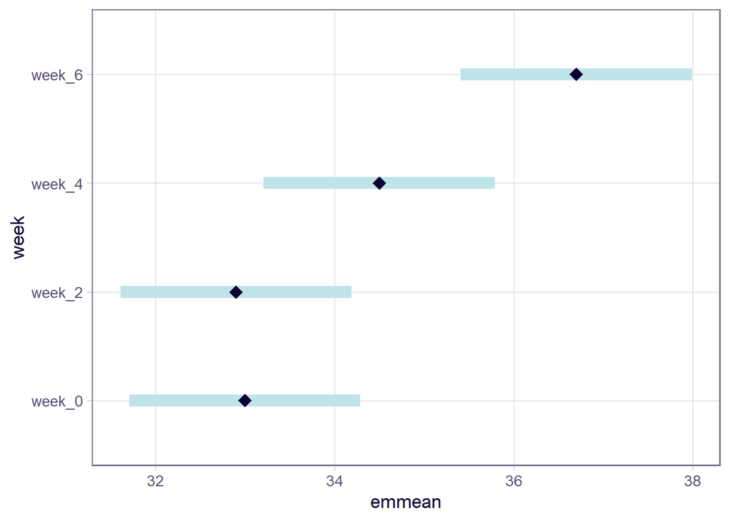

```r
# plot(emm)

emmeans:::plot.emmGrid(emm)
```

## 5.5 Mẫu biện luận

A repeated measures ANOVA was conducted to evaluate changes in `score` among 10 subjects across four time points (week 0, week 2, week 4, and week 6).

The mean `score` was 33.0 (SD = 2.16) at week 0, 32.9 (SD = 1.79) at week 2, 34.5 (SD = 2.37) at week 4, and 36.7 (SD = 1.64) at week 6.

The analysis revealed a statistically significant difference in `score` across the four time points (F(3, 27) = 7.281, p[GG] = 0.009), with a large effect size (generalized eta-squared $\eta^2$ is 0.394).

Bonferroni-adjusted pairwise comparisons demonstrated that `score` at week 6 was significantly higher than that at week 0 and week 2 (both p < 0.001).

However, no statistically significant differences were observed between the other time-point comparisons.

These findings suggest that `score` significantly increased over the six-week follow-up period, particularly between the initial measurements and week 6.

## 5.6 Vẽ đồ thị

### 5.6.1 Cách 1

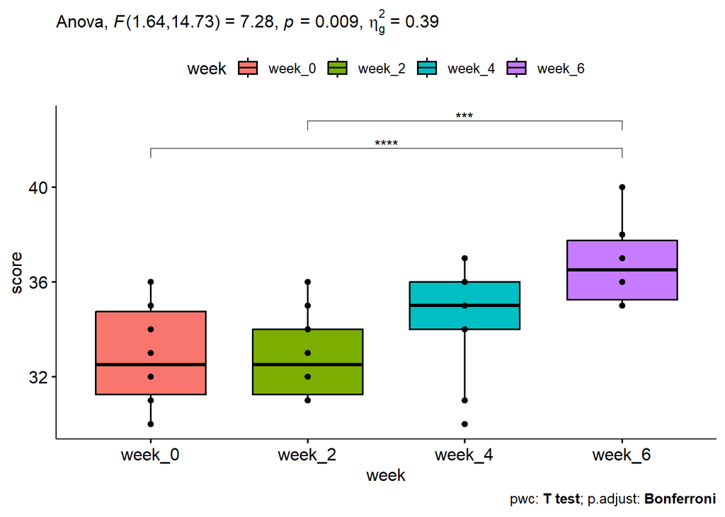

```r
ggboxplot(df_long,
          x = "week",
          y = "score",
          add = "point",
          color = "black",
          fill = "week") +

    stat_pvalue_manual(pwc,
                     # tip.length = 0,
                     hide.ns = TRUE) +

  labs(subtitle = get_test_label(res.aov,
                                 detailed = TRUE),
       caption  = get_pwc_label(pwc))
```

### 5.6.2 Cách 2

```r
library(ggstatsplot
        )
p2 <- ggstatsplot:::ggwithinstats(data = df_long,
                     x = week,
                     y = score,
                     type = "parametric",
                     var.equal = TRUE,
                     plot.type = "box",
                     pairwise.comparisons = T,
                     pairwise.display = "significant",
                     p.adjust.method = "bonferroni",
                     centrality.plotting = T,
                     centrality.path = T,
                     digits = 4L,
                     ggtheme = theme_classic(base_size = 12),
                     bf.message = T,
                     results.subtitle = T,
                     caption = "",
                     centrality.point.args = list(size = 4, color = "darkred"),
                     centrality.label.args = list(size = 4,
                                                  nudge_x = 0.4,
                                                  segment.linetype = 4),
                     ggsignif.args = list(size = 0.5,
                                          vjust = 0,
                                          step_increase = 0.1,
                                          textsize = 5),
                     point.path.args = list(alpha = 0.5,
                                            lwd = 0.8,
                                            linetype = "solid",
                                            color = "blue"),
                     point.args = list(position = ggplot2::position_jitterdodge(dodge.width = 0,                                                                 jitter.width = 0,                                                                jitter.height = 0),
                                       alpha = 0.5,
                                       size = 6,
                                       stroke = 0,
                                       na.rm = TRUE)
                     ) + coord_cartesian(ylim = c(28,45))

ggsave(filename = "p2_ok.png",
       width = 12,
       height = 8,
       plot = p2,
       dpi = 300,
       units = "in")
```

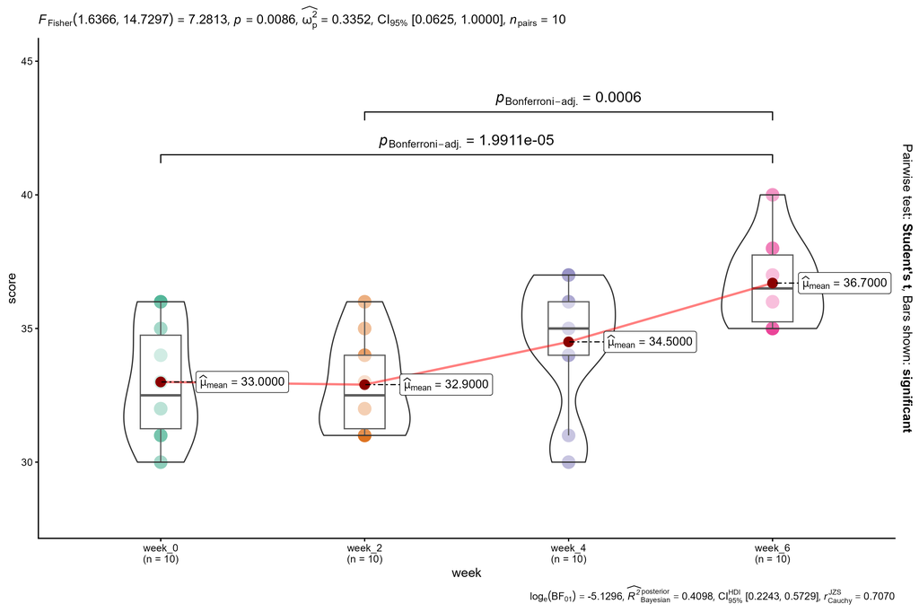

# 6 Phân tích repeated measures ANOVA | nonparametric

https://statfas.com/tutorials/friedman-test.html

https://www.datanovia.com/learn/biostatistics/anova/friedman-test-in-r

## 6.1 Friedman Rank Sum test

```r
friedman_result <- df_long %>%
  rstatix:::friedman_test(
    score ~ week | subject
  )

friedman_result
```

```
# A tibble: 1 × 6
  .y.       n statistic    df        p method
* <chr> <int>     <dbl> <dbl>    <dbl> <chr>
1 score    10      17.3     3 0.000616 Friedman test
```

```r
stats::friedman.test(
  score ~ week | subject,
  data = df_long
)
```

```
    Friedman rank sum test

data:  score and week and subject
Friedman chi-squared = 17.289, df = 3, p-value = 0.0006164
```

## 6.2 Effect size

```r
friedman_effect <- df_long %>%
  rstatix:::friedman_effsize(
    score ~ week | subject
  )

friedman_effect
```

```
# A tibble: 1 × 5
  .y.       n effsize method    magnitude
* <chr> <int>   <dbl> <chr>     <ord>
1 score    10   0.576 Kendall W large
```

Effect size is 0.576 (the benchmarks are 0.1 small, 0.3 moderate, ≥ 0.5 large), then week has a strong influence on `score`.

## 6.3 Post-hoc multiple comparison

```r
pwc <- df_long %>%
  rstatix:::wilcox_test(score ~ week,
                        paired = TRUE,
                        p.adjust.method = "bonferroni")

pwc <- pwc %>% add_xy_position(x = "week")

pwc_ori <- as.data.frame(pwc)

pwc_ori
```

```
    .y. group1 group2 n1 n2 statistic     p p.adj p.adj.signif y.position         groups xmin xmax
1 score week_0 week_2 10 10      30.5 0.794 1.000           ns     40.480 week_0, week_2    1    2
2 score week_0 week_4 10 10      17.0 0.306 1.000           ns     41.056 week_0, week_4    1    3
3 score week_0 week_6 10 10       0.0 0.005 0.033            *     41.632 week_0, week_6    1    4
4 score week_2 week_4 10 10       8.0 0.181 1.000           ns     42.208 week_2, week_4    2    3
5 score week_2 week_6 10 10       0.0 0.006 0.033            *     42.784 week_2, week_6    2    4
6 score week_4 week_6 10 10       7.5 0.082 0.492           ns     43.360 week_4, week_6    3    4
```

## 6.4 Vẽ đồ thị

### 6.4.1 Cách 1

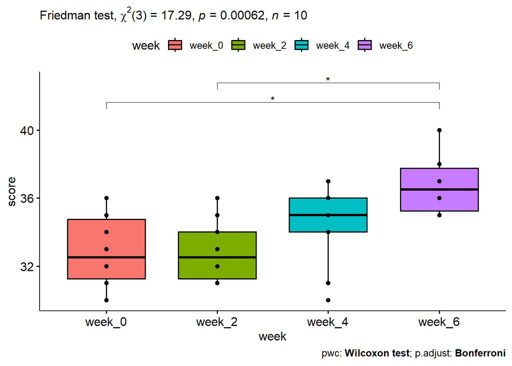

```r
library(rstatix)
library(ggpubr)


ggboxplot(df_long,
          x = "week",
          y = "score",
          add = "point",
          color = "black",
          fill = "week") +

  stat_pvalue_manual(pwc,
                     # tip.length = 0,
                     hide.ns = TRUE) +

  labs(subtitle = get_test_label(friedman_result,
                                 detailed = TRUE),

    caption = get_pwc_label(pwc))
```

### 6.4.2 Cách 2

```r
library(ggstatsplot
        )
p3 <- ggstatsplot:::ggwithinstats(data = df_long,
                     x = week,
                     y = score,
                     type = "nonparametric",
                     var.equal = F,
                     plot.type = "box",
                     pairwise.comparisons = T,
                     pairwise.display = "significant",
                     p.adjust.method = "bonferroni",
                     centrality.plotting = T,
                     centrality.path = T,
                     digits = 4L,
                     ggtheme = theme_classic(base_size = 12),
                     bf.message = T,
                     results.subtitle = T,
                     caption = "",
                     centrality.point.args = list(size = 4, color = "darkred"),
                     centrality.label.args = list(size = 4,
                                                  nudge_x = 0.4,
                                                  segment.linetype = 4),
                     ggsignif.args = list(size = 0.5,
                                          vjust = 0,
                                          step_increase = 0.1,
                                          textsize = 5),
                     point.path.args = list(alpha = 0.5,
                                            lwd = 0.8,
                                            linetype = "solid",
                                            color = "blue"),
                     point.args = list(position = ggplot2::position_jitterdodge(dodge.width = 0,                                                                 jitter.width = 0,                                                                jitter.height = 0),
                                       alpha = 0.5,
                                       size = 6,
                                       stroke = 0,
                                       na.rm = TRUE)
                     ) + coord_cartesian(ylim = c(28,46))

ggsave(filename = "p3_ok.png",
       width = 12,
       height = 8,
       plot = p3,
       dpi = 300,
       units = "in")
```

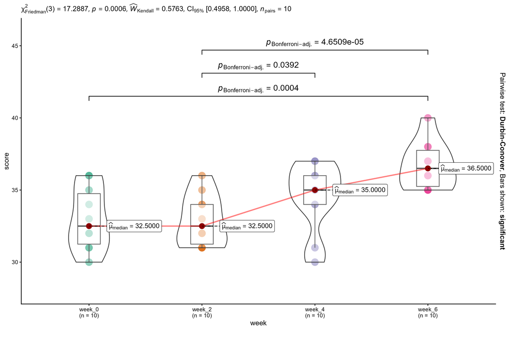

Thuật toán post-hoc hiệu chỉnh Bonferroni với test Durbin-Conover cho kết quả khác so với thuật toán Wilcoxon test, xuất hiện thêm 1 cặp có ý nghĩa thống kê.

```r
ggstatsplot:::extract_stats(p3)
```

```
$subtitle_data
# A tibble: 1 × 15
  parameter1 parameter2 statistic df.error  p.value method                 effectsize  estimate conf.level conf.low conf.high conf.method
  <chr>      <chr>          <dbl>    <dbl>    <dbl> <chr>                  <chr>          <dbl>      <dbl>    <dbl>     <dbl> <chr>
1 score      week            17.3        3 0.000616 Friedman rank sum test Kendall's W    0.576       0.95    0.496         1 percentile bootstrap
  conf.iterations n.obs expression
            <int> <int> <list>
1             100    10 <language>

$caption_data
NULL

$pairwise_comparisons_data
# A tibble: 6 × 9
  group1 group2 statistic   p.value alternative distribution p.adjust.method test           expression
  <chr>  <chr>      <dbl>     <dbl> <chr>       <chr>        <chr>           <chr>          <list>
1 week_0 week_2     0.769 1         two.sided   t            Bonferroni      Durbin-Conover <language>
2 week_0 week_4     2.18  0.230     two.sided   t            Bonferroni      Durbin-Conover <language>
3 week_0 week_6     4.74  0.000366  two.sided   t            Bonferroni      Durbin-Conover <language>
4 week_2 week_4     2.95  0.0392    two.sided   t            Bonferroni      Durbin-Conover <language>
5 week_2 week_6     5.51  0.0000465 two.sided   t            Bonferroni      Durbin-Conover <language>
6 week_4 week_6     2.56  0.0976    two.sided   t            Bonferroni      Durbin-Conover <language>

$descriptive_data
NULL

$one_sample_data
NULL

$tidy_data
NULL

$glance_data
NULL

attr(,"class")
[1] "ggstatsplot_stats" "list"
```

```r
pwc_ori
```

```
    .y. group1 group2 n1 n2 statistic     p p.adj p.adj.signif y.position         groups xmin xmax
1 score week_0 week_2 10 10      30.5 0.794 1.000           ns     40.480 week_0, week_2    1    2
2 score week_0 week_4 10 10      17.0 0.306 1.000           ns     41.056 week_0, week_4    1    3
3 score week_0 week_6 10 10       0.0 0.005 0.033            *     41.632 week_0, week_6    1    4
4 score week_2 week_4 10 10       8.0 0.181 1.000           ns     42.208 week_2, week_4    2    3
5 score week_2 week_6 10 10       0.0 0.006 0.033            *     42.784 week_2, week_6    2    4
6 score week_4 week_6 10 10       7.5 0.082 0.492           ns     43.360 week_4, week_6    3    4
```

## 6.5 Mẫu biện luận

The `score` differed significantly across the four time points, as assessed by a Friedman test, χ²(3) = 17.289, p = 0.0006164, with a large effect size (Kendall’s W = 0.576).

Pairwise Wilcoxon signed-rank tests (Bonferroni-adjusted) showed significant increases between `week_0` and `week_6` (p = 0.033), `week_2` and `week_6` (p = 0.033).